# Diseño completamente aleatorizado con bloques al azar

Gerardo Martín

3/3/2021

# 1 Introducción

El diseño completamente aleatorizado con bloques al azar es muy similar al diseño completamente aleatorizado con efectos aleatorios. La principal diferencia entre ambos diseños es que cada bloque cuenta con todos los tratamientos, mientras que en los diseños aleatorizados cada bloque cuenta con los tratamientos que se hayan asignado aleatoriamente:

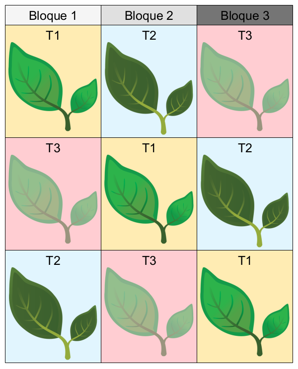

Figure 1.1: Esquema del diseño completamente aleatorizado con bloques aleatorios.

Como se puede notar, dentro de cada bloque no hay réplicas. La ausencia de réplicas dentro de los bloques no es un requerimiento, pero sí una característica del diseño, puede o no haber réplicas dentro de los bloques. Debido a que las réplicas son los bloques mismos que contienen los tratamientos, no existe pseudo-replicación simple.

# 2 Análisis del diseño aleatorizado por bloques

Para comenzar, simularemos una base de datos utilizando el mismo método que utilizamos anteriormente, por lo que omitiré el código y el nombre de los datos experimentales es `base.datos`. Afortunadamente el análisis de los datos de este diseño experimental es igual al diseño por completamente aleatorizado con efectos aleatorios. Para incrementar las herramientas analíticas utilizaremos entonces aprenderemos a utilizar un paquete llamado `lme4`.

## 2.1 Instalación y uso de paquetes en **R**

Cuando comenzamos una sesión en **R** hay una serie de funciones básicas. Sin embargo, esas funciones son muy limitadas y por lo general están contenidas en *paquetes* con nombres como `base`, `graphics` y `stats`. La principal bondad de **R** es que hay una cantidad enorme de paquetes disponibles para instalar y que contienen un sin fín de métodos estadísticos implementados o de funciones adicionales para manejar diferentes tipos de datos. Uno de dichos paquetes es `lme4` que contiene código y funciones para ajustar modelos lineales con efectos fijos y aleatorios. Primero para instalar el paquete corrermos la función:

`install.packages("lme4")`

y para abrirlo en la sesión actual:

```r
library(lme4)
```

nota que le argumento de `install.packages` está rodeado por `""`, y no así el de la función nativa `library`. Ahora, una vez que abrimos el paquete `lme4` en la sesión interactiva de **R**, podemos comenzar a usar las funciones que contiene.

## 2.2 El análisis con `lme4`

Haremos primero el ANOVA con efectos aleatorios que hicimos anteriormente. La función del paquete `lme4` para hacer un anova con efectos aleatorios es `lmer`, y los efectos aleatorios (efectos de `Bloque`) se especifican de una manera un tanto diferente:

```r
modelo.1 <- lmer(Valor ~ Tratamiento + (1|Bloque), data = base.datos)
modelo.1
```

```
## Linear mixed model fit by REML ['lmerMod']
## Formula: Valor ~ Tratamiento + (1 | Bloque)
##    Data: base.datos
## REML criterion at convergence: 288.886
## Random effects:
##  Groups   Name        Std.Dev.
##  Bloque   (Intercept) 1.457
##  Residual             6.759
## Number of obs: 45, groups:  Bloque, 3
## Fixed Effects:
##  (Intercept)  TratamientoB  TratamientoC
##       5.4828       -1.1669        0.9507
```

Cuando imprimimos los resultados del análisis, para comenzar a entender, hay que fijarnos en las últimas filas desués de `Fixed Effects`. La columna `(Intercept)` contiene la media del tratamiento A, y los valores de las columnas `Tratamiento B` y `Tratamiento C` muestran los efectos del los tratamientos en comparación con el `Tratamiento A`. Esto quiere decir que la media del `Tratamiento B` estimada por `lmer` es `5.4828 - 1.1669 = 4.3159`. Para ver la significancia estadística de los tratamientos podemos extraer el valor de $F$ con la función `anova` (última columna `F value`):

```r
anova(modelo.1)
```

```
## Analysis of Variance Table
##             npar Sum Sq Mean Sq F value
## Tratamiento    2 33.748  16.874  0.3694
```

```r
qf(0.05, 14, 30)
```

```
## [1] 0.4332367
```

Regresar al índice del curso